# PROJECT

WARDATUS SYIFA

2024-10-23

# Memanggil Library

```r
library(TSA)
```

```r
library(ggplot2)
library(tsibble)
library(tseries)
library(MASS)
library(readxl)
library(rio)
library(forecast)
library(TTR)
library(aTSA)
library(graphics)
library(Rssa)
library(lattice)
library(latticeExtra)
library(plyr)
library(fma)
library(fGarch)
library(rugarch)
library(FinTS)
library(MTS)
```

# Input Data

```r
data <- read_excel("C:/Users/Asus/Downloads/Data MPDW Kel 9.xlsx")
data
```

```
## # A tibble: 500 × 2
##    Periode  Kurs
##      <dbl> <dbl>
##  1       1 12953
##  2       2 12788
##  3       3 12870
##  4       4 13004
##  5       5 13228
##  6       6 13280
##  7       7 13038
##  8       8 13141
##  9       9 12970
## 10      10 12937
## # ℹ 490 more rows
```

```r
data_ts <- ts(data$Kurs)
data_ts
```

```
## Time Series:
## Start = 1
## End = 500
## Frequency = 1
##   [1] 12953 12788 12870 13004 13228 13280 13038 13141 12970 12937 12887 12970
##  [13] 13038 13158 13072 13175 13165 13275 13230 13290 13303 13260 13303 13331
##  [25] 13430 13492 13465 13675 13885 13795 14065 14235 14225 14670 14665 13410
##  [37] 13400 13478 13793 14620 13624 13736 13986 13850 14205 13947 13661 13812
##  [49] 14045 13986 13850 14104 13624 13550 13532 13441 13333 13038 13141 13280
##  [61] 13141 13141 13228 13210 13210 13405 13316 13624 13736 13477 13369 13333
##  [73] 13605 13123 13141 13158 13123 13123 13141 13106 13179 13310 13195 13176
##  [85] 13163 13053 12966 12967 13092 13050 13063 13115 13342 13479 13480 13640
##  [97] 13357 13383 13442 13512 13351 13313 13406 13326 13338 13335 13350 13324
## [109] 13278 13346 13330 13320 13335 13373 13287 13105 13322 13333 13323 13328
## [121] 13288 13304 13295 13277 13284 13298 13408 13332 13265 13320 13309 13351
```

[output cut: 31 more lines]

# Split Data

```r
train<-ts(data_ts[1:450])
test<-ts(data_ts[451:500])
```

# Eksplorasi Data

## Time Series Plot

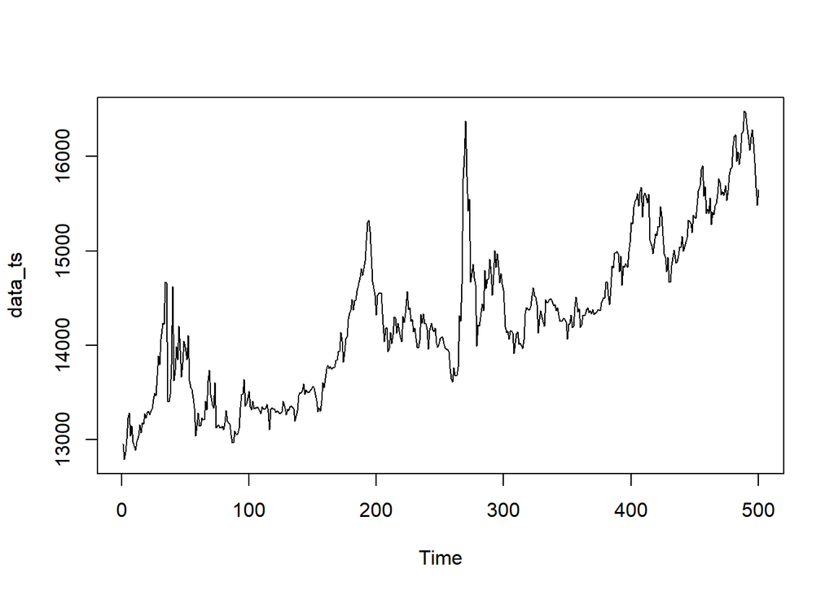

```r
ts.plot(data_ts)
```

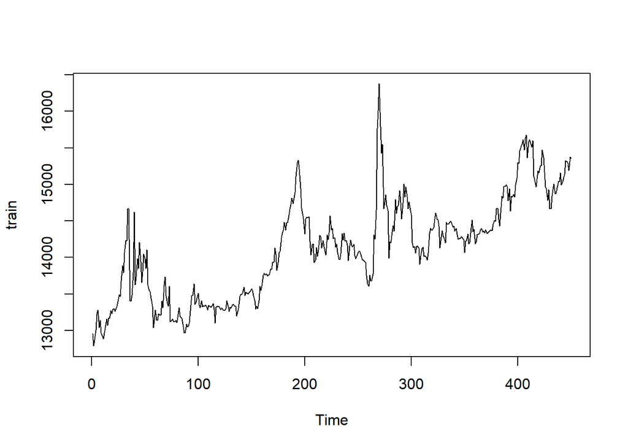

```r
ts.plot(train)
```

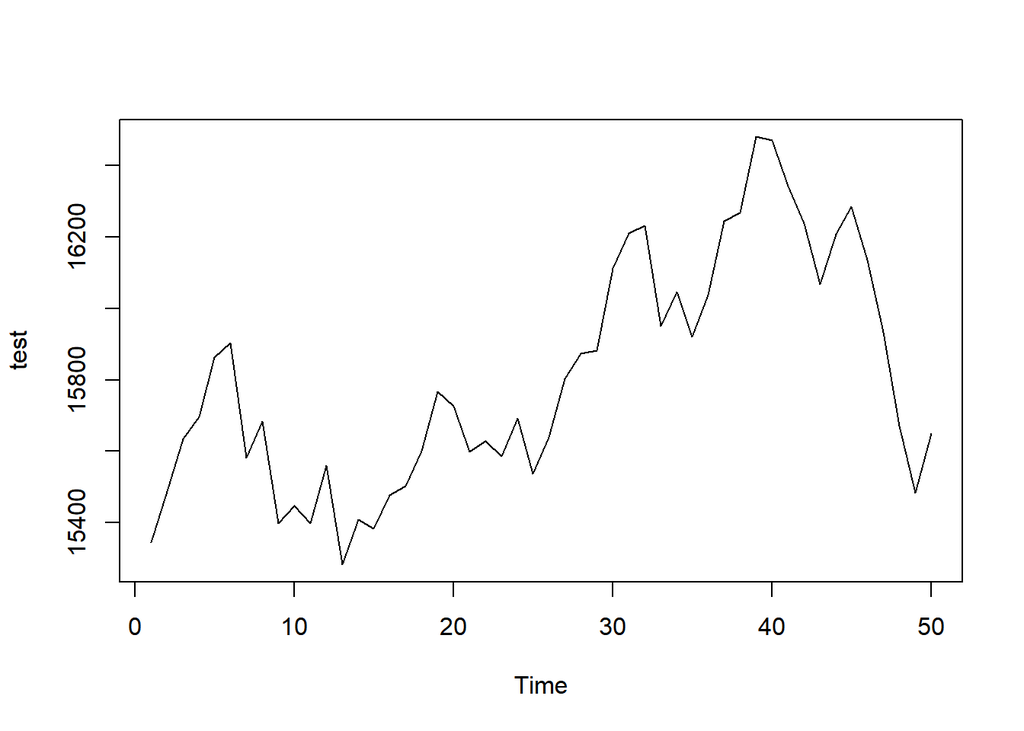

```r
ts.plot(test)
```

Dapat dilihat pada eksplorasi plot diatas data tidak stasioner dalam rataan.

## PLot ACF

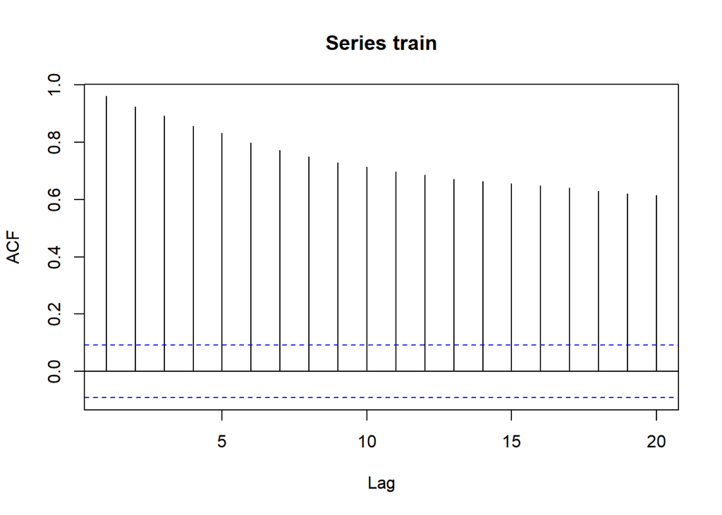

```r
acf(train,lag.max = 20)
```

Plot ACF menunjukkan pola *Tails-off slowly* yang menunjukkan data tersebut tidak stasioner dalam rataan.

## ADF Test

```r
adf.test(train)
```

```
## Augmented Dickey-Fuller Test
## alternative: stationary
##
## Type 1: no drift no trend
##      lag   ADF p.value
## [1,]   0 0.504   0.789
## [2,]   1 0.594   0.815
## [3,]   2 0.609   0.819
## [4,]   3 0.532   0.797
## [5,]   4 0.605   0.818
## [6,]   5 0.485   0.784
## Type 2: with drift no trend
##      lag   ADF p.value
## [1,]   0 -2.70  0.0784
## [2,]   1 -2.63  0.0898
## [3,]   2 -2.51  0.1235
## [4,]   3 -2.62  0.0923
## [5,]   4 -2.13  0.2765
## [6,]   5 -2.46  0.1462
## Type 3: with drift and trend
##      lag   ADF p.value
## [1,]   0 -4.59  0.0100
## [2,]   1 -4.41  0.0100
## [3,]   2 -4.29  0.0100
## [4,]   3 -4.61  0.0100
## [5,]   4 -3.96  0.0105
## [6,]   5 -4.62  0.0100
## ----
## Note: in fact, p.value = 0.01 means p.value <= 0.01
```

Dari tes ADF yang dilakukan didapat $p-value =0.01$ dimana $p-value< 0.05$ maka data tersebut stasioner dalam rataan.

## Boxcox dan Lambda Optimum

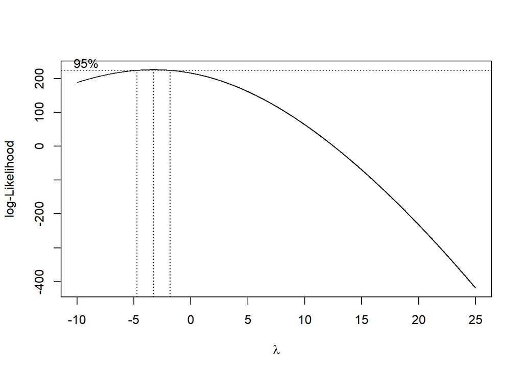

```r
index <- seq(1:450)
bc = boxcox(train~index, lambda = seq(-10,25,by=0.01))
```

```r
#Nilai Rounded Lambda
lambda <- bc$x[which.max(bc$y)]
lambda
```

```
## [1] -3.29
```

```r
#SK
bc$x[bc$y > max(bc$y) - 1/2 * qchisq(.95,1)]
```

```
##   [1] -4.74 -4.73 -4.72 -4.71 -4.70 -4.69 -4.68 -4.67 -4.66 -4.65 -4.64 -4.63
##  [13] -4.62 -4.61 -4.60 -4.59 -4.58 -4.57 -4.56 -4.55 -4.54 -4.53 -4.52 -4.51
##  [25] -4.50 -4.49 -4.48 -4.47 -4.46 -4.45 -4.44 -4.43 -4.42 -4.41 -4.40 -4.39
##  [37] -4.38 -4.37 -4.36 -4.35 -4.34 -4.33 -4.32 -4.31 -4.30 -4.29 -4.28 -4.27
##  [49] -4.26 -4.25 -4.24 -4.23 -4.22 -4.21 -4.20 -4.19 -4.18 -4.17 -4.16 -4.15
##  [61] -4.14 -4.13 -4.12 -4.11 -4.10 -4.09 -4.08 -4.07 -4.06 -4.05 -4.04 -4.03
##  [73] -4.02 -4.01 -4.00 -3.99 -3.98 -3.97 -3.96 -3.95 -3.94 -3.93 -3.92 -3.91
##  [85] -3.90 -3.89 -3.88 -3.87 -3.86 -3.85 -3.84 -3.83 -3.82 -3.81 -3.80 -3.79
##  [97] -3.78 -3.77 -3.76 -3.75 -3.74 -3.73 -3.72 -3.71 -3.70 -3.69 -3.68 -3.67
## [109] -3.66 -3.65 -3.64 -3.63 -3.62 -3.61 -3.60 -3.59 -3.58 -3.57 -3.56 -3.55
## [121] -3.54 -3.53 -3.52 -3.51 -3.50 -3.49 -3.48 -3.47 -3.46 -3.45 -3.44 -3.43
## [133] -3.42 -3.41 -3.40 -3.39 -3.38 -3.37 -3.36 -3.35 -3.34 -3.33 -3.32 -3.31
## [145] -3.30 -3.29 -3.28 -3.27 -3.26 -3.25 -3.24 -3.23 -3.22 -3.21 -3.20 -3.19
## [157] -3.18 -3.17 -3.16 -3.15 -3.14 -3.13 -3.12 -3.11 -3.10 -3.09 -3.08 -3.07
## [169] -3.06 -3.05 -3.04 -3.03 -3.02 -3.01 -3.00 -2.99 -2.98 -2.97 -2.96 -2.95
## [181] -2.94 -2.93 -2.92 -2.91 -2.90 -2.89 -2.88 -2.87 -2.86 -2.85 -2.84 -2.83
## [193] -2.82 -2.81 -2.80 -2.79 -2.78 -2.77 -2.76 -2.75 -2.74 -2.73 -2.72 -2.71
## [205] -2.70 -2.69 -2.68 -2.67 -2.66 -2.65 -2.64 -2.63 -2.62 -2.61 -2.60 -2.59
## [217] -2.58 -2.57 -2.56 -2.55 -2.54 -2.53 -2.52 -2.51 -2.50 -2.49 -2.48 -2.47
## [229] -2.46 -2.45 -2.44 -2.43 -2.42 -2.41 -2.40 -2.39 -2.38 -2.37 -2.36 -2.35
## [241] -2.34 -2.33 -2.32 -2.31 -2.30 -2.29 -2.28 -2.27 -2.26 -2.25 -2.24 -2.23
## [253] -2.22 -2.21 -2.20 -2.19 -2.18 -2.17 -2.16 -2.15 -2.14 -2.13 -2.12 -2.11
## [265] -2.10 -2.09 -2.08 -2.07 -2.06 -2.05 -2.04 -2.03 -2.02 -2.01 -2.00 -1.99
## [277] -1.98 -1.97 -1.96 -1.95 -1.94 -1.93 -1.92 -1.91 -1.90 -1.89 -1.88 -1.87
## [289] -1.86 -1.85
```

Dari kurva boxcox dapat dilihat kurva tidak melewati $\lambda=1$ yang menunjukkan data tidak stasioner dalam ragam. Dan juga didapat $\lambda$ optimum $-3.29$

# Penanganan Ketidakstasioneran Data

# Ketidakstasioneran Dalam Ragam (Transformasi Box-Cox)

```r
lambda<- -3.29
data$Kurs_tr <- data$Kurs^lambda
data_tr <- ts(data$Kurs_tr)
train_tr<-data_tr[1:450]
test_tr<-data_tr[451:500]

data_tr
```

```
## Time Series:
## Start = 1
## End = 500
## Frequency = 1
##   [1] 2.953259e-14 3.080487e-14 3.016384e-14 2.915324e-14 2.756031e-14
##   [6] 2.720685e-14 2.890386e-14 2.816518e-14 2.940543e-14 2.965292e-14
##  [11] 3.003312e-14 2.940543e-14 2.890386e-14 2.804564e-14 2.865726e-14
##  [16] 2.792675e-14 2.799660e-14 2.724058e-14 2.754661e-14 2.713956e-14
##  [21] 2.705240e-14 2.734210e-14 2.705240e-14 2.686591e-14 2.621983e-14
##  [26] 2.582551e-14 2.599627e-14 2.470581e-14 2.349763e-14 2.400577e-14
##  [31] 2.252269e-14 2.164980e-14 2.169991e-14 1.960852e-14 1.963053e-14
##  [36] 2.634871e-14 2.641346e-14 2.591387e-14 2.401722e-14 1.983002e-14
##  [41] 2.501139e-14 2.434668e-14 2.294396e-14 2.369356e-14 2.180059e-14
##  [46] 2.315571e-14 2.478921e-14 2.390870e-14 2.262838e-14 2.294396e-14
##  [51] 2.369356e-14 2.231844e-14 2.501139e-14 2.546360e-14 2.557520e-14
```

[output cut: 89 more lines]

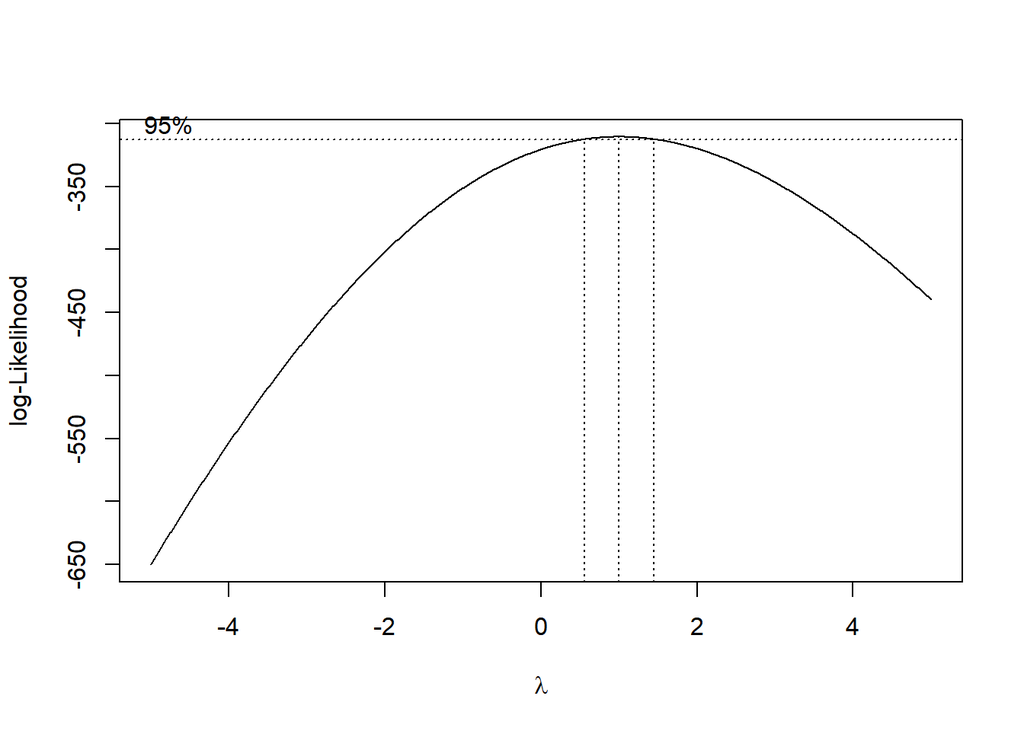

```r
index <- seq(1:450)
bc = boxcox(train_tr~index, lambda = seq(-5,5,by=0.01))
```

```r
#Nilai Rounded Lambda
lambda <- bc$x[which.max(bc$y)]
lambda
```

```
## [1] 1
```

```r
#SK
bc$x[bc$y > max(bc$y) - 1/2 * qchisq(.95,1)]
```

```
##  [1] 0.57 0.58 0.59 0.60 0.61 0.62 0.63 0.64 0.65 0.66 0.67 0.68 0.69 0.70 0.71
## [16] 0.72 0.73 0.74 0.75 0.76 0.77 0.78 0.79 0.80 0.81 0.82 0.83 0.84 0.85 0.86
## [31] 0.87 0.88 0.89 0.90 0.91 0.92 0.93 0.94 0.95 0.96 0.97 0.98 0.99 1.00 1.01
## [46] 1.02 1.03 1.04 1.05 1.06 1.07 1.08 1.09 1.10 1.11 1.12 1.13 1.14 1.15 1.16
## [61] 1.17 1.18 1.19 1.20 1.21 1.22 1.23 1.24 1.25 1.26 1.27 1.28 1.29 1.30 1.31
## [76] 1.32 1.33 1.34 1.35 1.36 1.37 1.38 1.39 1.40 1.41 1.42 1.43 1.44
```

# Ketidakstasioneran Dalam Rataan (*Differencing*)

### Plot ACF

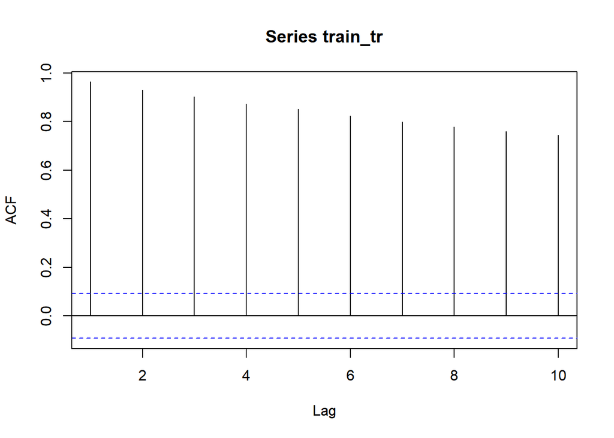

```r
acf(train_tr, lag.max = 10)
```

Berdasarkan plot tersebut, terlihat bahwa plot ACF **tidak cuts off** pada lag tertentu. Hal ini menandakan data belum stasioner dalam rataan dan **masih diperlukan penanganan** kestasioneran data.

### Uji ADF

```r
tseries::adf.test(train_tr)
```

```
##
##  Augmented Dickey-Fuller Test
##
## data:  train_tr
## Dickey-Fuller = -3.9525, Lag order = 7, p-value = 0.01148
## alternative hypothesis: stationary
```

$H_0$ : Data tidak stasioner dalam rataan

$H_1$ : Data stasioner dalam rataan

Berdasarkan uji ADF tersebut, didapat *p-value =* $0.01148$ yang lebih kecil dari taraf nyata 5% sehingga tolak $H_0$ atau data stasioner dalam rataan. Hal ini tidak sesuai dengan hasil eksplorasi menggunakan plot time series dan plot ACF, sehingga dalam hal ini ketidakstasioneran data **belum berhasil** ditangani

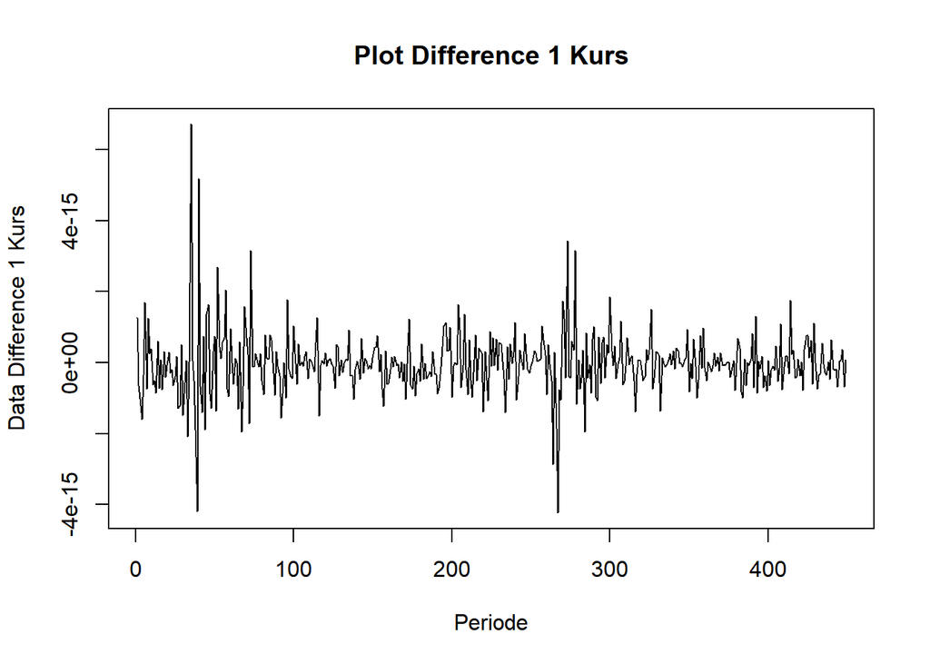

```r
data.diff<-diff(train_tr,differences = 1)
plot.ts(data.diff, lty=1, xlab="Periode", ylab="Data Difference 1 Kurs", main="Plot Difference 1 Kurs")
```

Berdasarkan plot data deret waktu, terlihat bahwa data sudah stasioner dalam rataan ditandai dengan terdapat data yang bergerak pada suatu nilai tengah tertentu.

# Identifikasi Model

## Plot ACF

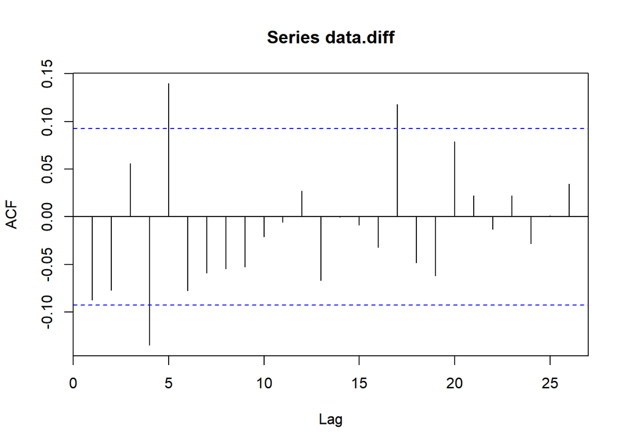

```r
acf(data.diff)
```

## Plot PACF

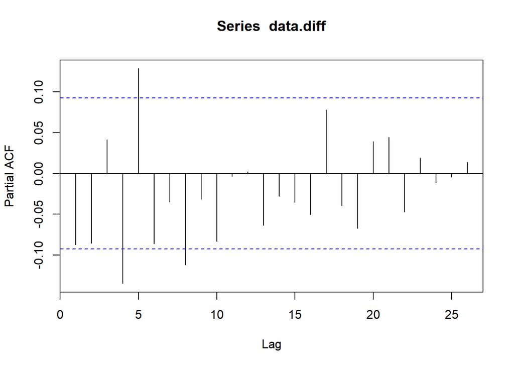

```r
pacf(data.diff)
```

## Plot EACF

```r
eacf(data.diff)
```

```
## AR/MA
##   0 1 2 3 4 5 6 7 8 9 10 11 12 13
## 0 o o o x x o o o o o o  o  o  o
## 1 x x o o o x o o o o o  o  o  o
## 2 x x o o o x o o o o o  o  o  o
## 3 x x x o o x o o o o o  o  o  o
## 4 x x x o o x o o o o o  o  o  o
## 5 x x o x x x o o o o o  o  o  o
## 6 x x x x x o o o o o o  o  o  o
## 7 x x x o x o x o o o o  o  o  o
```

Berdasarkan plot EACF diatas, model tentatif yang terbentuk adalah ARIMA(1,1,2), ARIMA(2,1,2), ARIMA(0,1,5), ARIMA (1,1,6).